# Benchmarking CMEnt on Simulated Microarray Data

CMEnt vs comb-p, probeLasso, DMRcate, and Bumphunter

CMEnt Package

2026-06-08

# Contents

## 1 Introduction

This vignette provides an extended benchmark comparing CMEnt against multiple popular DMR detection methods on a simulated microarray dataset with known ground truth. The methods compared include:

- **CMEnt**: Correlation-based seed-guided assembly approach
- **comb-p**: Combines adjacent p-values using Stouffer-Liptak-Kechris correction
- **probeLasso**: Lasso-based feature selection for DMR detection
- **DMRcate**: Gaussian kernel smoothing approach
- **Bumphunter**: Permutation-based regional testing

The dataset used is a simulated dataset, produced by running `simulateDMRs`, with default parameters, on chr21 and chr22 subset of preprocessed beta values from 656 450K illumina microarray healthy blood samples found in GEO with identifier GSE40279, with 500 simulated DMRs of varying widths and effect sizes. The simulated dataset is available for download from Zenodo (see code below).

## 2 Setup and Dependencies

```r
try(devtools::load_all(), silent = TRUE)
suppressPackageStartupMessages({
    try(library(CMEnt), silent = TRUE)
    library(minfi)
    library(data.table)
    library(ggplot2)
    library(dplyr)
    library(GenomicRanges)
})

getBenchmarkFile <- function(filename) {
    benchmark_file <- ""
    folder <- "simulated_microarray450k"
    if (getwd() == "notebooks") {
        benchmark_file <- file.path("cached_results", folder, filename)
    } else if ("NAMESPACE" %in% dir()) {
        benchmark_file <- file.path("notebooks", "cached_results", folder, filename)
    } else {
        benchmark_file <- file.path("cached_results", folder, filename)
    }
    dir.create(dirname(benchmark_file), showWarnings = FALSE, recursive = TRUE)
    benchmark_file
}

get_method_cache_file <- function(method) {
    getBenchmarkFile(sprintf("dmrs.%s.rds", method))
}
```

### 2.1 Install External Dependencies

```r
r <- getOption("repos")
if (is.null(r) || is.na(r["CRAN"]) || r["CRAN"] %in% c("@CRAN@", "")) {
  options(repos = c(CRAN = "https://cloud.r-project.org"))
}
if (!requireNamespace("BiocManager", quietly = TRUE)) {
    install.packages("BiocManager")
}

if (!requireNamespace("DMRcate", quietly = TRUE)) {
    BiocManager::install("DMRcate", update = FALSE, ask = FALSE)
}

if (!requireNamespace("bumphunter", quietly = TRUE)) {
    BiocManager::install("bumphunter", update = FALSE, ask = FALSE)
}

if (!requireNamespace("doParallel", quietly = TRUE)) {
    install.packages("doParallel")
}

if (!requireNamespace("tidyr", quietly = TRUE)) {
    install.packages("tidyr")
}

if (!requireNamespace("ChAMP", quietly = TRUE)) {
    BiocManager::install("ChAMP", update = FALSE, ask = FALSE)
}
```

**Note:** comb-p requires both the Python tool itself (combined-pvalues) and bedtools, installing using new conda env if not present:

```bash
{ command -v comb-p >/dev/null 2>&1 && command -v bedtools >/dev/null 2>&1; } || {
    echo >&2 "comb-p or bedtools not found. Installing with conda...";
    conda create -n cment_microarray_exp python=3.9
    conda activate cment_microarray_exp
    conda install -yc bioconda combined-pvalues bedtools
}
```

## 3 Load Data

```r
sim_beta_path <- getBenchmarkFile("GSE40279_sim_beta_values.tsv.gz")
sim_truth_path <- getBenchmarkFile("GSE40279_sim_dmrs.tsv")
sim_pheno_path <- getBenchmarkFile("GSE40279_sim_samplesheet.tsv")
covariate_cols <- c("age..y..ch1", "predictedSex")
array_type <- "450K"
genome <- "hg19"
zenodo_base_url <- "https://zenodo.org/records/20592944/files/"
if (!file.exists(sim_beta_path)) {
    curl::curl_download(
        url = paste0(zenodo_base_url, basename(sim_beta_path), "?download=1"),
        destfile = sim_beta_path
    )
}
if (!file.exists(sim_truth_path)) {
    curl::curl_download(
        url = paste0(zenodo_base_url, basename(sim_truth_path), "?download=1"),
        destfile = sim_truth_path
    )
}
if (!file.exists(sim_pheno_path)) {
    curl::curl_download(
        url = paste0(zenodo_base_url, basename(sim_pheno_path), "?download=1"),
        destfile = sim_pheno_path
    )
}

truth_df <- data.table::fread(sim_truth_path)
truth_dmrs <- makeGRangesFromDataFrame(
    truth_df,
    seqnames.field = "seqnames",
    start.field = "start",
    end.field = "end",
    keep.extra.columns = TRUE
)

beta_handler <- CMEnt::getBetaHandler(sim_beta_path, array = array_type, genome = genome)

sample_ids <- beta_handler$getBetaColNames()
pheno <- data.table::fread(sim_pheno_path, data.table = FALSE)
rownames(pheno) <- pheno$V1

if (!all(sample_ids %in% rownames(pheno))) {
    stop("The simulated phenotype file does not contain all simulated beta samples.")
}
pheno <- pheno[sample_ids, , drop = FALSE]
pheno$Sample_Group <- factor(pheno$Sample_Group, levels = c("control", "case"))

beta_mat <- as.matrix(beta_handler$getBeta())
locs <- beta_handler$getBetaLocs()
truth_probe_counts <- countOverlaps(truth_dmrs, makeGRangesFromDataFrame(
    as.data.frame(locs),
    seqnames.field = "chr",
    start.field = "start",
    end.field = "end",
    keep.extra.columns = TRUE
))
truth_overlap_n <- sum(truth_probe_counts > 0L)
if (truth_overlap_n < 0.9 * length(truth_dmrs)) {
    stop(
        sprintf(
            paste(
                "Only %d/%d truth DMRs overlap probe loci under genome='%s'.",
                "This simulated microarray truth set was generated on hg19;",
                "delete stale cache files and rerun with genome='hg19'."
            ),
            truth_overlap_n,
            length(truth_dmrs),
            genome
        )
    )
}
logit2 <- function(x) log2(x) - log2(1 - x)
mvalues <- logit2(beta_mat)
pheno$casecontrol <- pheno$Sample_Group == "case"
```

## 4 Find Differentially Methylated Positions

```r
dmps <- CMEnt::findDMPsArray(beta_handler,
    pheno,
    group_col = "Sample_Group",
    id_col = "V1"
)
rownames(dmps) <- dmps$site_id
# sort DMPs by location
dmps <- dmps[!is.na(dmps$pval), ]
dmp_locs <- locs[rownames(locs) %in% rownames(dmps), , drop = FALSE]
dmps <- dmps[rownames(dmp_locs), , drop = FALSE]

case_idx <- which(pheno$casecontrol)
ctrl_idx <- which(!pheno$casecontrol)
dmps$delta_beta <- rowMeans(beta_mat[rownames(dmps), case_idx, drop = FALSE]) -
    rowMeans(beta_mat[rownames(dmps), ctrl_idx, drop = FALSE])

dmps$qval <- stats::p.adjust(dmps$pval, method = "fdr")

dmps_gr <- makeGRangesFromDataFrame(
    data.frame(
        chr = dmp_locs$chr,
        start = dmp_locs$start,
        end = dmp_locs$end,
        id = rownames(dmps),
        pval = dmps$pval,
        qval = dmps$qval,
        delta_beta = dmps$delta_beta
    ),
    keep.extra.columns = TRUE
)
dmps_gr <- sort(dmps_gr)
names(dmps_gr) <- rownames(dmps)

seeds_gr <- dmps_gr[mcols(dmps_gr)$qval < 0.05]
seeds <- mcols(seeds_gr)$id
cat(sprintf("Found %d significant DMPs to be used as seeds (FDR < 0.05)\n", length(seeds)))
```

Found 4827 significant DMPs to be used as seeds (FDR < 0.05)

## 5 Method 1: CMEnt

```r
cment_params <- list(
    sample_group_col = "Sample_Group",
    casecontrol_col = "casecontrol",
    max_bridge_seeds_gaps = 0,
    max_bridge_extension_gaps = 1,
    min_seeds = 2,
    min_sites = 3,
    ext_site_delta_beta = 0.1,
    max_lookup_dist = 500,
    max_pval = 0.05,
    testing_mode = "parametric",
    entanglement = "weak"
)
cment_njobs <- max(1L, min(8L, future::availableCores() - 1L))
options("CMEnt.njobs" = cment_njobs)
```

### 5.1 Assessing DMPs seeds connectivity alone

```r
# only chr21
truth_dmrs_21 <- truth_dmrs[seqnames(truth_dmrs) == "chr21", ]
seeds_gr_21 <- subset(seeds_gr, seqnames(seeds_gr) == "chr21")
seeds_21 <- mcols(seeds_gr_21)$id
seeds_beta_21 <- beta_mat[mcols(seeds_gr_21)$id, , drop = FALSE]
gt_seeds_gr_21 <- subsetByOverlaps(seeds_gr_21, truth_dmrs_21, ignore.strand = TRUE)
seeds_dmrs_cment <- do.call(CMEnt::buildDMRs, c(cment_params, list(
    beta = seeds_beta_21,
    seeds = seeds_21,
    pheno = pheno,
    verbose = 2,
    .score_dmrs = FALSE,
    extract_motifs = FALSE,
    annotate_with_genes = FALSE)))
```

```r
seeds_in_truth <- subsetByOverlaps(gt_seeds_gr_21, truth_dmrs_21, ignore.strand = TRUE)

seeds_in_dmrs <- subsetByOverlaps(gt_seeds_gr_21, seeds_dmrs_cment, ignore.strand = TRUE)
seeds_in_truth_and_dmrs <- subsetByOverlaps(seeds_in_truth, seeds_dmrs_cment, ignore.strand = TRUE)
seeds_in_truth_not_dmrs <- subsetByOverlaps(seeds_in_truth, seeds_dmrs_cment, ignore.strand = TRUE, invert = TRUE)



seed_truth_ov <- findOverlaps(seeds_in_truth, truth_dmrs_21, ignore.strand = TRUE)
truth_seed_total <- tabulate(subjectHits(seed_truth_ov), nbins = length(truth_dmrs_21))
seed_truth_hit_ov <- findOverlaps(seeds_in_truth_and_dmrs, truth_dmrs_21, ignore.strand = TRUE)


truth_seed_captured <- tabulate(subjectHits(seed_truth_hit_ov), nbins = length(truth_dmrs_21))
truth_seed_capture_pct <- ifelse(truth_seed_total > 0, round(100 * truth_seed_captured / truth_seed_total, 1), NA_real_)

recoverable_truth <- truth_seed_total >= 2L
recoverable_with2captured <- recoverable_truth & truth_seed_captured >= 2L
recoverable_fully_captured <- recoverable_truth & truth_seed_captured == truth_seed_total

stage1_quality <- data.frame(
    Truth_DMRs_Total = length(truth_dmrs_21),
    Truth_DMRs_With_Seeds = sum(truth_seed_total >= 1L),
    Truth_DMRs_2plusSeeds = sum(recoverable_truth),
    Truth_DMRs_With2plusCapturedSeeds = sum(recoverable_with2captured),
    Truth_DMRs_Stage1Recoverable_FullyCapturedSeeds = sum(recoverable_fully_captured),
    Seed_Capture_Rate_Pct_in_Truth = ifelse(length(seeds_in_truth) == 0, NA_real_, round(100 * length(seeds_in_truth_and_dmrs) / length(seeds_in_truth), 1)),
    Median_Seed_Capture_Pct_Per_Truth = ifelse(sum(truth_seed_total > 0) == 0, NA_real_, stats::median(truth_seed_capture_pct[truth_seed_total > 0], na.rm = TRUE))
)

for (col in colnames(stage1_quality)) {
    cat(sprintf("- **%s**: %s\n", col, stage1_quality[[col]]))
}
```

```r
seeds_beta_21_handler <- CMEnt::getBetaHandler(
    beta = seeds_beta_21,
    genome = genome,
    array = array_type
)
group_inds <- split(seq_len(nrow(pheno)), pheno$Sample_Group)
testing_mode_per_group <- rep("parametric", length(group_inds))
names(testing_mode_per_group) <- names(group_inds)
empirical_strategy_per_group <- rep("permutation", length(group_inds))
names(empirical_strategy_per_group) <- names(group_inds)

connectivity_array_21 <- CMEnt:::.buildConnectivityArray(
    beta_handler = seeds_beta_21_handler,
    pheno = pheno,
    group_inds = group_inds,
    testing_mode_per_group = testing_mode_per_group,
    empirical_strategy_per_group = empirical_strategy_per_group,
    col_names = NULL,
    max_pval = cment_params$max_pval,
    ext_site_delta_beta = NA_real_,
    max_lookup_dist = cment_params$max_lookup_dist,
    entanglement = cment_params$entanglement,
    njobs = cment_njobs,
    max_bridge_gaps = 1,
    verbose = 3
)$connectivity_array
connectivity_array_21_no_gaps <- CMEnt:::.buildConnectivityArray(
    beta_handler = seeds_beta_21_handler,
    pheno = pheno,
    group_inds = group_inds,
    testing_mode_per_group = testing_mode_per_group,
    empirical_strategy_per_group = empirical_strategy_per_group,
    col_names = NULL,
    max_pval = cment_params$max_pval,
    ext_site_delta_beta = NA_real_,
    max_lookup_dist = cment_params$max_lookup_dist,
    entanglement = cment_params$entanglement,
    njobs = cment_njobs,
    max_bridge_gaps = 0,
    verbose = 2
)$connectivity_array

truth_hits <- findOverlaps(gt_seeds_gr_21, truth_dmrs_21, ignore.strand = TRUE)

truth_id <- rep(NA_integer_, length(gt_seeds_gr_21))
truth_id[queryHits(truth_hits)] <- subjectHits(truth_hits)

gt_vec <- rep(FALSE, length(gt_seeds_gr_21))
if (length(gt_vec) > 1L) {
    gt_vec[-length(gt_vec)] <- !is.na(truth_id[-length(truth_id)]) &
        truth_id[-length(truth_id)] == truth_id[-1]
}

gt_connectivity <- data.frame(gt = gt_vec)

colnames(connectivity_array_21_no_gaps) <- paste(colnames(connectivity_array_21_no_gaps), "ngaps", sep = "_")
connectivity_array_21 <- cbind(gt_connectivity, connectivity_array_21, connectivity_array_21_no_gaps)
x <- rle(connectivity_array_21$connected); sum(x$values)
```

```r
seeds_in_truth <- subsetByOverlaps(gt_seeds_gr_21, truth_dmrs_21, ignore.strand = TRUE)

seeds_in_dmrs <- subsetByOverlaps(gt_seeds_gr_21, seeds_dmrs_cment, ignore.strand = TRUE)
seeds_in_truth_and_dmrs <- subsetByOverlaps(seeds_in_truth, seeds_dmrs_cment, ignore.strand = TRUE)
seeds_in_truth_not_dmrs <- subsetByOverlaps(seeds_in_truth, seeds_dmrs_cment, ignore.strand = TRUE, invert = TRUE)



seed_truth_ov <- findOverlaps(seeds_in_truth, truth_dmrs_21, ignore.strand = TRUE)
truth_seed_total <- tabulate(subjectHits(seed_truth_ov), nbins = length(truth_dmrs_21))
seed_truth_hit_ov <- findOverlaps(seeds_in_truth_and_dmrs, truth_dmrs_21, ignore.strand = TRUE)


truth_seed_captured <- tabulate(subjectHits(seed_truth_hit_ov), nbins = length(truth_dmrs_21))
truth_seed_capture_pct <- ifelse(truth_seed_total > 0, round(100 * truth_seed_captured / truth_seed_total, 1), NA_real_)

recoverable_truth <- truth_seed_total >= 2L
recoverable_with2captured <- recoverable_truth & truth_seed_captured >= 2L
recoverable_fully_captured <- recoverable_truth & truth_seed_captured == truth_seed_total

stage1_quality <- data.frame(
    Truth_DMRs_Total = length(truth_dmrs_21),
    Truth_DMRs_With_Seeds = sum(truth_seed_total >= 1L),
    Truth_DMRs_2plusSeeds = sum(recoverable_truth),
    Truth_DMRs_With2plusCapturedSeeds = sum(recoverable_with2captured),
    Truth_DMRs_Stage1Recoverable_FullyCapturedSeeds = sum(recoverable_fully_captured),
    Seed_Capture_Rate_Pct_in_Truth = ifelse(length(seeds_in_truth) == 0, NA_real_, round(100 * length(seeds_in_truth_and_dmrs) / length(seeds_in_truth), 1)),
    Median_Seed_Capture_Pct_Per_Truth = ifelse(sum(truth_seed_total > 0) == 0, NA_real_, stats::median(truth_seed_capture_pct[truth_seed_total > 0], na.rm = TRUE))
)

for (col in colnames(stage1_quality)) {
    cat(sprintf("- **%s**: %s\n", col, stage1_quality[[col]]))
}
```

```r
cment_file <- get_method_cache_file("CMEnt")

cment_cache_valid <- FALSE
if (file.exists(cment_file)) {
    ret <- readRDS(cment_file)
    cment_cache_valid <- identical(ret$params, cment_params)
    if (cment_cache_valid) {
        dmrs_cment <- ret$dmrs
        time_cment <- ret$time
    }
}
if (!cment_cache_valid) {
    cment_njobs <- max(1L, min(8L, future::availableCores() - 1L))
    options("CMEnt.njobs" = cment_njobs)
    cat(sprintf("CMEnt parallel jobs: %d\n", cment_njobs))
    start_time <- Sys.time()
    dmrs_cment <- do.call(CMEnt::buildDMRs,
        c(list(
            beta = beta_handler,
            seeds = seeds,
            pheno = pheno,
            verbose = 2,
            .score_dmrs = FALSE,
            extract_motifs = FALSE,
            annotate_with_genes = FALSE
        ), cment_params)
    )
    end_time <- Sys.time()
    time_cment <- end_time - start_time
    saveRDS(list(dmrs = dmrs_cment, time = time_cment, params = cment_params), cment_file)
}

cat(sprintf("CMEnt: Found %d DMRs in %d seconds\n", length(dmrs_cment), round(as.numeric(time_cment, units = "secs"))))
```

CMEnt: Found 539 DMRs in 101 seconds

## 6 Method 2: comb-p

```r
combp_file <- get_method_cache_file("combp")

run_combp <- function(dmps_gr, seed = 500, dist = 500) {
    if (Sys.which("bedtools") == "") {
        warning("bedtools not found in PATH. comb-p requires bedtools to be installed.")
        warning("Install with: conda install -yc bioconda bedtools")
        return(GRanges())
    }

    if (Sys.which("comb-p") == "") {
        warning("comb-p not found in PATH.")
        warning("Install with: conda install -yc bioconda combined-pvalues")
        return(GRanges())
    }
    tmpdir <- tempdir()
    bed_file <- file.path(tmpdir, "dmps_for_combp.bed")
    bed_df <- data.frame(
        chrom = as.character(seqnames(dmps_gr)),
        start = start(dmps_gr) - 1,
        end = end(dmps_gr),
        pval = mcols(dmps_gr)$pval
    )
    bed_df <- bed_df[order(bed_df$chrom, bed_df$start), ]

    write.table(bed_df, bed_file,
        quote = FALSE, sep = "\t",
        row.names = FALSE, col.names = TRUE
    )

    cmd <- sprintf(
        "comb-p pipeline -c 4 --seed %d --dist %d -p %s --region-filter-p 0.01 --region-filter-n 3 %s",
        seed, dist, file.path(tmpdir, "output."), bed_file
    )

    tryCatch(
        {
            exit_code <- system(cmd, ignore.stdout = FALSE, ignore.stderr = FALSE)

            if (exit_code != 0) {
                warning(sprintf("comb-p exited with code %d", exit_code))
                return(GRanges())
            }

            regions_file <- paste0(file.path(tmpdir, "output."), "regions-p.bed.gz")
            if (file.exists(regions_file)) {
                regions <- fread(cmd = sprintf("zcat %s", regions_file))
                colnames(regions) <- c("chr", "start", "end", "min_p", "n_probes", "z_p", "z_sidak_p")

                regions <- regions[regions$z_sidak_p < 0.05 & regions$n_probes >= 3, ]

                dmrs_combp <- makeGRangesFromDataFrame(regions,
                    seqnames.field = "chr",
                    start.field = "start",
                    end.field = "end",
                    keep.extra.columns = TRUE
                )
                return(dmrs_combp)
            } else {
                warning("comb-p did not produce output file")
                return(GRanges())
            }
        },
        error = function(e) {
            warning(sprintf("comb-p failed: %s", e$message))
            GRanges()
        }
    )
}

if (!file.exists(combp_file)) {
    start_time <- Sys.time()
    dmrs_combp <- run_combp(dmps_gr)
    end_time <- Sys.time()
    time_combp <- end_time - start_time
    saveRDS(list(dmrs = dmrs_combp, time = time_combp), combp_file)
} else {
    ret <- readRDS(combp_file)
    dmrs_combp <- ret$dmrs
    time_combp <- ret$time
}

cat(sprintf("comb-p: Found %d DMRs in %d seconds\n", length(dmrs_combp), round(as.numeric(time_combp, units = "secs"))))
```

comb-p: Found 503 DMRs in 8 seconds

## 7 Method 3: probeLasso

```r
probelasso_file <- get_method_cache_file("probeLasso")

run_probelasso_champ <- function(beta_mat, pheno, array_type = "450K") {
    if (!requireNamespace("ChAMP", quietly = TRUE)) {
        warning("ChAMP not installed. probeLasso requires ChAMP.")
        warning("Install with: BiocManager::install('ChAMP')")
        return(GRanges())
    }

    library(ChAMP)

    tryCatch(
        {
            result <- champ.DMR(
                beta = beta_mat,
                pheno = pheno$Sample_Group,
                arraytype = array_type,
                method = "ProbeLasso",
                minProbes = cment_params$min_sites,
                adjPvalDmr = 0.05,
                adjPvalProbe = 0.1,
                meanLassoRadius = 500,
                minDmrSep = 500,
                minDmrSize = 50,
                PDFplot = FALSE,
                Rplot = FALSE,
                resultsDir = file.path(tempdir(), "champ_probelasso")
            )

            pl_dmr <- result$ProbeLassoDMR
            if (is.null(pl_dmr) || nrow(pl_dmr) == 0) {
                return(GRanges())
            }

            # ChAMP output column names can differ by version.
            if (!"seqnames" %in% names(pl_dmr) && "dmrChrom" %in% names(pl_dmr)) {
                pl_dmr$seqnames <- pl_dmr$dmrChrom
            }
            if (!"start" %in% names(pl_dmr) && "dmrStart" %in% names(pl_dmr)) {
                pl_dmr$start <- pl_dmr$dmrStart
            }
            if (!"end" %in% names(pl_dmr) && "dmrEnd" %in% names(pl_dmr)) {
                pl_dmr$end <- pl_dmr$dmrEnd
            }

            return(makeGRangesFromDataFrame(pl_dmr,
                seqnames.field = "seqnames",
                start.field = "start",
                end.field = "end",
                keep.extra.columns = TRUE
            ))
        },
        error = function(e) {
            warning(sprintf("probeLasso (ChAMP) failed: %s", e$message))
            GRanges()
        }
    )
}

if (!file.exists(probelasso_file)) {
    start_time <- Sys.time()
    dmrs_probelasso <- run_probelasso_champ(beta_mat, pheno, array_type = "450K")
    end_time <- Sys.time()
    time_probelasso <- end_time - start_time
    saveRDS(list(dmrs = dmrs_probelasso, time = time_probelasso), probelasso_file)
} else {
    ret <- readRDS(probelasso_file)
    dmrs_probelasso <- ret$dmrs
    time_probelasso <- ret$time
}

cat(sprintf("probeLasso: Found %d DMRs in %d seconds\n", length(dmrs_probelasso), round(as.numeric(time_probelasso, units = "secs"))))
```

probeLasso: Found 289 DMRs in 18 seconds

## 8 Method 4: DMRcate

```r
dmrcate_file <- get_method_cache_file("dmrcate")
if (!file.exists(dmrcate_file)) {
    library(DMRcate)
    start_time <- Sys.time()
    formula_str <- "~Sample_Group"
    design <- model.matrix(stats::as.formula(formula_str), data = pheno)
    coef_col <- which(colnames(design) == "Sample_Groupcase")
    colnames(design)[1] <- "(Intercept)"
    colnames(design)[coef_col] <- "case_vs_control"

    myannotation <- cpg.annotate("array", mvalues,
        what = "M", arraytype = "450K",
        analysis.type = "differential", design = design,
        coef = coef_col, fdr = 0.05
    )

    dmrcate_results <- dmrcate(myannotation, C = 2, lambda = 1000, min.cpgs = 3, betacutoff = 0.05)
    dmrs_dmrcate <- extractRanges(dmrcate_results, genome = genome)

    end_time <- Sys.time()
    time_dmrcate <- end_time - start_time
    saveRDS(list(dmrs = dmrs_dmrcate, time = time_dmrcate), dmrcate_file)
} else {
    ret <- readRDS(dmrcate_file)
    dmrs_dmrcate <- ret$dmrs
    time_dmrcate <- ret$time
}

cat(sprintf("DMRcate: Found %d DMRs in %d seconds\n", length(dmrs_dmrcate), round(as.numeric(time_dmrcate, units = "secs"))))
```

DMRcate: Found 482 DMRs in 7 seconds

## 9 Method 5: Bumphunter

```r
bumphunter_file <- get_method_cache_file("bumphunter")
if (!file.exists(bumphunter_file)) {
    suppressPackageStartupMessages({
        library(bumphunter)
        library(doParallel)
    })
    start_time <- Sys.time()
    bh_cores <- max(1L, min(8L, future::availableCores() - 1L))
    bh_b <- 100L
    bh_max_dmrs <- 100000L
    bh_max_gap <- 2000L
    bh_min_l <- 2L
    bh_region_p <- 0.05
    formula_str <- "~Sample_Group"
    design <- model.matrix(stats::as.formula(formula_str), data = pheno)
    coef_col <- which(colnames(design) == "Sample_Groupcase")
    colnames(design)[1] <- "(Intercept)"
    colnames(design)[coef_col] <- "case_vs_control"

    doParallel::registerDoParallel(cores = bh_cores)
    on.exit({
        try(doParallel::stopImplicitCluster(), silent = TRUE)
        gc()
    }, add = TRUE)

    bh_cluster <- bumphunter::clusterMaker(
        chr = as.character(locs$chr),
        pos = locs$start,
        maxGap = bh_max_gap
    )
    run_bumphunter_fit <- function(cutoff, B) {
        bumphunter(beta_mat,
            design = design,
            chr = as.character(locs$chr),
            pos = locs$start,
            cluster = bh_cluster,
            cutoff = cutoff,
            maxGap = max_gap,
            nullMethod = "bootstrap",
            B = B,
            type = "Beta",
            coef = coef_col
        )
    }
    has_informative_bumphunter_null <- function(fit) {
        null_values <- unlist(fit$null$value, use.names = FALSE)
        null_lengths <- unlist(fit$null$length, use.names = FALSE)
        length(null_values) > 0 &&
            any(abs(null_values) > 0) &&
            length(null_lengths) > 0 &&
            any(null_lengths > 0)
    }
    max_gap <- bh_max_gap
    dmrs_cutoff <- 0.1
    dmrs_cnt <- Inf
    iter <- 0L
    max_iter <- 10L
    while (dmrs_cnt > bh_max_dmrs && iter < max_iter) {
        iter <- iter + 1L
        dmrs <- run_bumphunter_fit(cutoff = dmrs_cutoff, B = 0)
        dmrs_cnt <- nrow(dmrs$table)
        dmrs_cutoff <- dmrs_cutoff * 1.2
        rm(dmrs)
        gc()
    }
    final_cutoff <- dmrs_cutoff / 1.2
    cat(sprintf(
        "Bumphunter: cutoff=%.4f, candidate_bumps=%d, minL=%d, maxGap=%d, cores=%d, B=%d\n",
        final_cutoff, dmrs_cnt, bh_min_l, max_gap, bh_cores, bh_b
    ))
    bumphunter_results <- run_bumphunter_fit(cutoff = final_cutoff, B = bh_b)
    bh_cutoff_floor <- 0.005
    bh_bootstrap_adjust_iter <- 0L
    bh_max_bootstrap_adjust <- 6L
    while (
        nrow(bumphunter_results$table) > 0 &&
            (all(is.na(bumphunter_results$table$p.value)) ||
                !has_informative_bumphunter_null(bumphunter_results)) &&
            final_cutoff > bh_cutoff_floor &&
            bh_bootstrap_adjust_iter < bh_max_bootstrap_adjust
    ) {
        prev_cutoff <- final_cutoff
        final_cutoff <- max(final_cutoff / 2, bh_cutoff_floor)
        if (identical(final_cutoff, prev_cutoff)) {
            break
        }
        bh_bootstrap_adjust_iter <- bh_bootstrap_adjust_iter + 1L
        cat(sprintf(
            "Bumphunter: bootstrap null degenerate at cutoff=%.4f; retrying with cutoff=%.4f\n",
            prev_cutoff, final_cutoff
        ))
        bumphunter_results <- run_bumphunter_fit(cutoff = final_cutoff, B = bh_b)
    }

    dmr_table <- bumphunter_results$table
    # bumphunter already estimates region-level p-values from the bootstrap null.
    dmr_table <- dmr_table[dmr_table$L >= bh_min_l & dmr_table$p.value <= bh_region_p, ]

    dmrs_bumphunter <- makeGRangesFromDataFrame(dmr_table,
        seqnames.field = "chr",
        start.field = "start",
        end.field = "end",
        keep.extra.columns = TRUE
    )
    end_time <- Sys.time()
    time_bumphunter <- end_time - start_time
    saveRDS(list(dmrs = dmrs_bumphunter, time = time_bumphunter), bumphunter_file)
} else {
    ret <- readRDS(bumphunter_file)
    dmrs_bumphunter <- ret$dmrs
    time_bumphunter <- ret$time
}

cat(sprintf("Bumphunter: Found %d DMRs in %d seconds\n", length(dmrs_bumphunter), round(as.numeric(time_bumphunter, units = "secs"))))
```

Bumphunter: Found 494 DMRs in 76 seconds

## 10 Comparative Analysis

### 10.1 Basic Statistics

```r
get_dmr_stats <- function(dmrs, method) {
    if (length(dmrs) == 0) {
        return(data.frame(
            Method = method,
            `Number of DMRs` = 0,
            `Mean DMR Width` = NA,
            `Median DMR Width` = NA,
            `Total Coverage bp` = 0,
            `Min Width` = NA,
            `Max Width` = NA
        ))
    }

    data.frame(
        Method = method,
        `Number of DMRs` = length(dmrs),
        `Mean DMR Width` = round(mean(width(dmrs)), 1),
        `Median DMR Width` = median(width(dmrs)),
        `Total Coverage bp` = sum(width(dmrs)),
        `Min Width` = min(width(dmrs)),
        `Max Width` = max(width(dmrs))
    )
}

stats_list <- list(
    get_dmr_stats(dmrs_cment, "CMEnt"),
    get_dmr_stats(dmrs_combp, "comb-p"),
    get_dmr_stats(dmrs_probelasso, "probeLasso"),
    get_dmr_stats(dmrs_dmrcate, "DMRcate"),
    get_dmr_stats(dmrs_bumphunter, "Bumphunter")
)

results_comparison <- do.call(rbind, stats_list)
knitr::kable(results_comparison, digits = 2, caption = "Basic DMR Statistics Across Methods")
```

Table 1: Basic DMR Statistics Across Methods

| Method | Number.of.DMRs | Mean.DMR.Width | Median.DMR.Width | Total.Coverage.bp | Min.Width | Max.Width |
| --- | --- | --- | --- | --- | --- | --- |
| CMEnt | 539 | 943.6 | 894.0 | 508603 | 37 | 2907 |
| comb-p | 503 | 992.7 | 927.0 | 499318 | 45 | 2909 |
| probeLasso | 289 | 1023.1 | 718.0 | 295668 | 53 | 6998 |
| DMRcate | 482 | 1539.1 | 1430.5 | 741850 | 43 | 7249 |
| Bumphunter | 494 | 916.9 | 828.5 | 452968 | 43 | 5578 |

### 10.2 Pairwise Overlap Analysis

```r
methods_list <- list(
    CMEnt = dmrs_cment,
    `comb-p` = dmrs_combp,
    probeLasso = dmrs_probelasso,
    DMRcate = dmrs_dmrcate,
    Bumphunter = dmrs_bumphunter
)

methods_list <- methods_list[sapply(methods_list, length) > 0]
method_order <- names(methods_list)

calculate_overlap <- function(gr1, gr2) {
    if (length(gr1) == 0 || length(gr2) == 0) {
        return(list(count = 0, percentage = 0))
    }
    overlap_count <- length(subsetByOverlaps(gr1, gr2))
    pct <- (overlap_count / length(gr1)) * 100
    list(count = overlap_count, percentage = pct)
}

overlap_matrix <- matrix(0, nrow = length(methods_list), ncol = length(methods_list))
pct_matrix <- matrix(0, nrow = length(methods_list), ncol = length(methods_list))
rownames(overlap_matrix) <- colnames(overlap_matrix) <- names(methods_list)
rownames(pct_matrix) <- colnames(pct_matrix) <- names(methods_list)

for (i in seq_along(methods_list)) {
    for (j in seq_along(methods_list)) {
        if (i == j) {
            overlap_matrix[i, j] <- length(methods_list[[i]])
            pct_matrix[i, j] <- 100
        } else {
            overlap_result <- calculate_overlap(methods_list[[i]], methods_list[[j]])
            overlap_matrix[i, j] <- overlap_result$count
            pct_matrix[i, j] <- overlap_result$percentage
        }
    }
}

cat("\n#### Overlap Counts (rows overlap with columns)\n")
```

#### 10.2.1 Overlap Counts (rows overlap with columns)

```r
knitr::kable(overlap_matrix, digits = 0, caption = "Number of DMRs from Method A (rows) overlapping with Method B (columns)")
```

Table 2: Number of DMRs from Method A (rows) overlapping with Method B (columns)

|  | CMEnt | comb-p | probeLasso | DMRcate | Bumphunter |
| --- | --- | --- | --- | --- | --- |
| CMEnt | 539 | 504 | 281 | 496 | 501 |
| comb-p | 503 | 503 | 277 | 493 | 500 |
| probeLasso | 286 | 283 | 289 | 279 | 282 |
| DMRcate | 482 | 482 | 270 | 482 | 482 |
| Bumphunter | 494 | 494 | 274 | 487 | 494 |

```r
cat("\n#### Overlap Percentages\n")
```

#### 10.2.2 Overlap Percentages

```r
knitr::kable(pct_matrix, digits = 2, caption = "Percentage of DMRs from Method A (rows) overlapping with Method B (columns)")
```

Table 2: Percentage of DMRs from Method A (rows) overlapping with Method B (columns)

|  | CMEnt | comb-p | probeLasso | DMRcate | Bumphunter |
| --- | --- | --- | --- | --- | --- |
| CMEnt | 100.00 | 93.51 | 52.13 | 92.02 | 92.95 |
| comb-p | 100.00 | 100.00 | 55.07 | 98.01 | 99.40 |
| probeLasso | 98.96 | 97.92 | 100.00 | 96.54 | 97.58 |
| DMRcate | 100.00 | 100.00 | 56.02 | 100.00 | 100.00 |
| Bumphunter | 100.00 | 100.00 | 55.47 | 98.58 | 100.00 |

### 10.3 Jaccard Index and IoU

```r
jaccard_index <- function(gr1, gr2) {
    if (length(gr1) == 0 || length(gr2) == 0) {
        return(0)
    }
    overlap_count <- length(subsetByOverlaps(gr1, gr2))
    total_unique <- length(unique(c(gr1, gr2)))
    if (total_unique == 0) {
        return(0)
    }
    overlap_count / total_unique
}

iou <- function(gr1, gr2) {
    if (length(gr1) == 0 || length(gr2) == 0) {
        return(0)
    }
    intersection <- sum(width(GenomicRanges::intersect(gr1, gr2)))
    union <- sum(width(GenomicRanges::union(gr1, gr2)))
    if (union == 0) {
        return(0)
    }
    intersection / union
}

jaccard_matrix <- matrix(0, nrow = length(methods_list), ncol = length(methods_list))
iou_matrix <- matrix(0, nrow = length(methods_list), ncol = length(methods_list))
rownames(jaccard_matrix) <- colnames(jaccard_matrix) <- names(methods_list)
rownames(iou_matrix) <- colnames(iou_matrix) <- names(methods_list)

for (i in seq_along(methods_list)) {
    for (j in seq_along(methods_list)) {
        if (i < j) {
            jaccard_matrix[i, j] <- jaccard_matrix[j, i] <- jaccard_index(methods_list[[i]], methods_list[[j]])
            iou_matrix[i, j] <- iou_matrix[j, i] <- iou(methods_list[[i]], methods_list[[j]])
        } else if (i == j) {
            jaccard_matrix[i, j] <- 1
            iou_matrix[i, j] <- 1
        }
    }
}

cat("\n#### Jaccard Index\n")
```

#### 10.3.1 Jaccard Index

```r
knitr::kable(jaccard_matrix, digits = 4, caption = "Jaccard Index (region count-based similarity)")
```

Table 3: Jaccard Index (region count-based similarity)

[output not shown]

```r
cat("\n#### Intersection over Union (IoU)\n")
```

#### 10.3.2 Intersection over Union (IoU)

```r
knitr::kable(iou_matrix, digits = 4, caption = "IoU (genomic coverage-based similarity)")
```

Table 3: IoU (genomic coverage-based similarity)

|  | CMEnt | comb-p | probeLasso | DMRcate | Bumphunter |
| --- | --- | --- | --- | --- | --- |
| CMEnt | 1.0000 | 0.9538 | 0.1706 | 0.6338 | 0.8631 |
| comb-p | 0.9538 | 1.0000 | 0.1716 | 0.6553 | 0.8850 |
| probeLasso | 0.1706 | 0.1716 | 1.0000 | 0.1462 | 0.1744 |
| DMRcate | 0.6338 | 0.6553 | 0.1462 | 1.0000 | 0.6027 |
| Bumphunter | 0.8631 | 0.8850 | 0.1744 | 0.6027 | 1.0000 |

## 11 Visualizations

### 11.1 DMR Count and Coverage Comparison

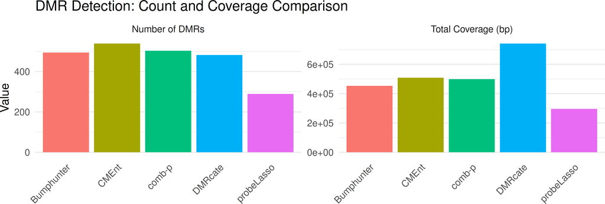

```r
viz_data <- results_comparison |>
    dplyr::select(Method, Number.of.DMRs, Total.Coverage.bp) |>
    tidyr::pivot_longer(
        cols = c(Number.of.DMRs, Total.Coverage.bp),
        names_to = "Metric", values_to = "Value"
    )

viz_data$Metric <- ifelse(viz_data$Metric == "Number.of.DMRs",
    "Number of DMRs",
    "Total Coverage (bp)"
)

p1 <- ggplot(viz_data, aes(x = Method, y = Value, fill = Method)) +
    geom_bar(stat = "identity") +
    facet_wrap(~Metric, scales = "free_y") +
    theme_minimal() +
    theme(
        axis.text.x = element_text(angle = 45, hjust = 1),
        legend.position = "none",
        panel.grid.major.x = element_blank()
    ) +
    labs(
        title = "DMR Detection: Count and Coverage Comparison",
        y = "Value", x = ""
    )

print(p1)
```

## 12 Ground-Truth Evaluation

```r
evaluate_against_truth <- function(pred, truth) {
    n_pred <- length(pred)
    n_truth <- length(truth)
    pred_overlap_truth <- sum(overlapsAny(pred, truth))
    truth_overlap_pred <- sum(overlapsAny(truth, pred))
    fp <- n_pred - pred_overlap_truth
    fn <- n_truth - truth_overlap_pred

    precision <- ifelse(n_pred == 0, 0, pred_overlap_truth / n_pred)
    recall <- ifelse(n_truth == 0, 0, truth_overlap_pred / n_truth)
    f1 <- ifelse(precision + recall == 0, 0, 2 * precision * recall / (precision + recall))

    pred_red <- reduce(pred)
    truth_red <- reduce(truth)
    inter <- GenomicRanges::intersect(pred_red, truth_red)

    pred_bp <- sum(width(pred_red))
    truth_bp <- sum(width(truth_red))
    inter_bp <- ifelse(length(inter) == 0, 0, sum(width(inter)))
    union_bp <- pred_bp + truth_bp - inter_bp

    precision_bp <- ifelse(pred_bp == 0, 0, inter_bp / pred_bp)
    recall_bp <- ifelse(truth_bp == 0, 0, inter_bp / truth_bp)
    f1_bp <- ifelse(precision_bp + recall_bp == 0, 0, 2 * precision_bp * recall_bp / (precision_bp + recall_bp))
    iou_bp <- ifelse(union_bp == 0, 0, inter_bp / union_bp)

    data.frame(
        TP_regions = truth_overlap_pred,
        FP_regions = fp,
        FN_regions = fn,
        Precision_regions = precision,
        Recall_regions = recall,
        F1_regions = f1,
        Predicted_bp = pred_bp,
        Truth_bp = truth_bp,
        Intersect_bp = inter_bp,
        Precision_bp = precision_bp,
        Recall_bp = recall_bp,
        F1_bp = f1_bp,
        IoU_bp = iou_bp
    )
}

truth_eval <- do.call(rbind, lapply(names(methods_list), function(method) {
    out <- evaluate_against_truth(methods_list[[method]], truth_dmrs)
    out$Method <- method
    out
}))
truth_eval$Method <- factor(truth_eval$Method, levels = method_order)
truth_eval <- truth_eval[order(truth_eval$Method), , drop = FALSE]
truth_eval$Method <- as.character(truth_eval$Method)


truth_eval <- truth_eval |>
    dplyr::select(
        Method,
        TP_regions,
        FP_regions, FN_regions,
        Precision_regions, Recall_regions, F1_regions,
        Precision_bp, Recall_bp, F1_bp, IoU_bp
    )

regions_truth_eval <- truth_eval |>
    dplyr::select(Method, TP_regions, FP_regions, FN_regions, Precision_regions, Recall_regions, F1_regions) |>
    dplyr::rename_with(~ sub("_regions$", "", .), ends_with("_regions"))

bp_truth_eval <- truth_eval |>
    dplyr::select(Method, Precision_bp, Recall_bp, F1_bp, IoU_bp) |>
    dplyr::rename_with(~ sub("_bp$", "", .), ends_with("_bp"))
```

```r
knitr::kable(regions_truth_eval, digits = 4, caption = "Macro (Region-level) Performance Against Ground Truth")
```

Table 4: Macro (Region-level) Performance Against Ground Truth

| Method | TP | FP | FN | Precision | Recall | F1 |
| --- | --- | --- | --- | --- | --- | --- |
| CMEnt | 500 | 38 | 0 | 0.9295 | 1.000 | 0.9635 |
| comb-p | 500 | 3 | 0 | 0.9940 | 1.000 | 0.9970 |
| probeLasso | 276 | 7 | 224 | 0.9758 | 0.552 | 0.7051 |
| DMRcate | 493 | 0 | 7 | 1.0000 | 0.986 | 0.9930 |
| Bumphunter | 500 | 0 | 0 | 1.0000 | 1.000 | 1.0000 |

```r
knitr::kable(bp_truth_eval, digits = 4, caption = "Micro (Base-pair-level) Performance Against Ground Truth")
```

Table 5: Micro (Base-pair-level) Performance Against Ground Truth

| Method | Precision | Recall | F1 | IoU |
| --- | --- | --- | --- | --- |
| CMEnt | 0.9646 | 0.9936 | 0.9789 | 0.9586 |
| comb-p | 0.9888 | 1.0000 | 0.9944 | 0.9888 |
| probeLasso | 0.3909 | 0.2341 | 0.2928 | 0.1715 |
| DMRcate | 0.6572 | 0.9875 | 0.7892 | 0.6518 |
| Bumphunter | 0.9870 | 0.9055 | 0.9445 | 0.8949 |

### 12.1 Overlap Matrices (Methods + Truth)

```r
all_sets <- c(methods_list, list(`Ground Truth` = truth_dmrs))

calculate_overlap <- function(gr1, gr2) {
    if (length(gr1) == 0 || length(gr2) == 0) {
        return(list(count = 0, percentage = 0))
    }
    overlap_count <- sum(overlapsAny(gr1, gr2))
    pct <- overlap_count / length(gr1) * 100
    list(count = overlap_count, percentage = pct)
}

overlap_count_mat <- matrix(0, nrow = length(all_sets), ncol = length(all_sets))
overlap_pct_mat <- matrix(0, nrow = length(all_sets), ncol = length(all_sets))
rownames(overlap_count_mat) <- colnames(overlap_count_mat) <- names(all_sets)
rownames(overlap_pct_mat) <- colnames(overlap_pct_mat) <- names(all_sets)

for (i in seq_along(all_sets)) {
    for (j in seq_along(all_sets)) {
        if (i == j) {
            overlap_count_mat[i, j] <- length(all_sets[[i]])
            overlap_pct_mat[i, j] <- 100
        } else {
            ov <- calculate_overlap(all_sets[[i]], all_sets[[j]])
            overlap_count_mat[i, j] <- ov$count
            overlap_pct_mat[i, j] <- ov$percentage
        }
    }
}

knitr::kable(overlap_count_mat, digits = 0, caption = "Overlap Counts (query=row, reference=column)")
```

Table 6: Overlap Counts (query=row, reference=column)

|  | CMEnt | comb-p | probeLasso | DMRcate | Bumphunter | Ground Truth |
| --- | --- | --- | --- | --- | --- | --- |
| CMEnt | 539 | 504 | 281 | 496 | 501 | 501 |
| comb-p | 503 | 503 | 277 | 493 | 500 | 500 |
| probeLasso | 286 | 283 | 289 | 279 | 282 | 282 |
| DMRcate | 482 | 482 | 270 | 482 | 482 | 482 |
| Bumphunter | 494 | 494 | 274 | 487 | 494 | 494 |
| Ground Truth | 500 | 500 | 276 | 493 | 500 | 500 |

```r
knitr::kable(overlap_pct_mat, digits = 2, caption = "Overlap Percentages (query=row, reference=column)")
```

Table 7: Overlap Percentages (query=row, reference=column)

|  | CMEnt | comb-p | probeLasso | DMRcate | Bumphunter | Ground Truth |
| --- | --- | --- | --- | --- | --- | --- |
| CMEnt | 100.00 | 93.51 | 52.13 | 92.02 | 92.95 | 92.95 |
| comb-p | 100.00 | 100.00 | 55.07 | 98.01 | 99.40 | 99.40 |
| probeLasso | 98.96 | 97.92 | 100.00 | 96.54 | 97.58 | 97.58 |
| DMRcate | 100.00 | 100.00 | 56.02 | 100.00 | 100.00 | 100.00 |
| Bumphunter | 100.00 | 100.00 | 55.47 | 98.58 | 100.00 | 100.00 |
| Ground Truth | 100.00 | 100.00 | 55.20 | 98.60 | 100.00 | 100.00 |

## 13 Visualizations

### 13.1 Ground-Truth Metrics

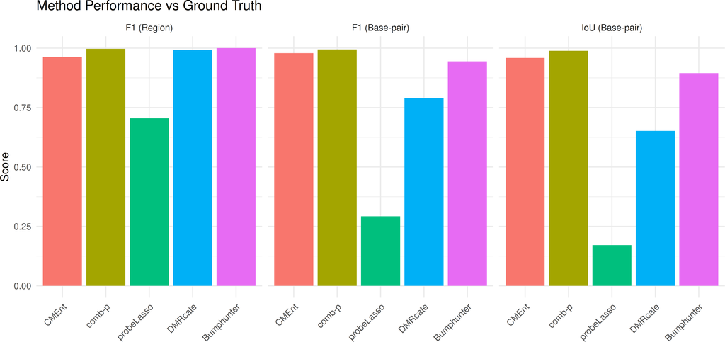

```r
plot_df <- truth_eval |>
    dplyr::select(Method, F1_regions, F1_bp, IoU_bp) |>
    tidyr::pivot_longer(
        cols = c(F1_regions, F1_bp, IoU_bp),
        names_to = "Metric",
        values_to = "Value"
    )

plot_df$Metric <- factor(
    plot_df$Metric,
    levels = c("F1_regions", "F1_bp", "IoU_bp"),
    labels = c("F1 (Region)", "F1 (Base-pair)", "IoU (Base-pair)")
)
plot_df$Method <- factor(plot_df$Method, levels = method_order)

ggplot(plot_df, aes(x = Method, y = Value, fill = Method)) +
    geom_col() +
    facet_wrap(~Metric, nrow = 1) +
    theme_minimal() +
    theme(
        axis.text.x = element_text(angle = 45, hjust = 1),
        legend.position = "none"
    ) +
    ylim(0, 1) +
    labs(
        title = "Method Performance vs Ground Truth",
        x = "",
        y = "Score"
    )
```

### 13.2 Width Distributions

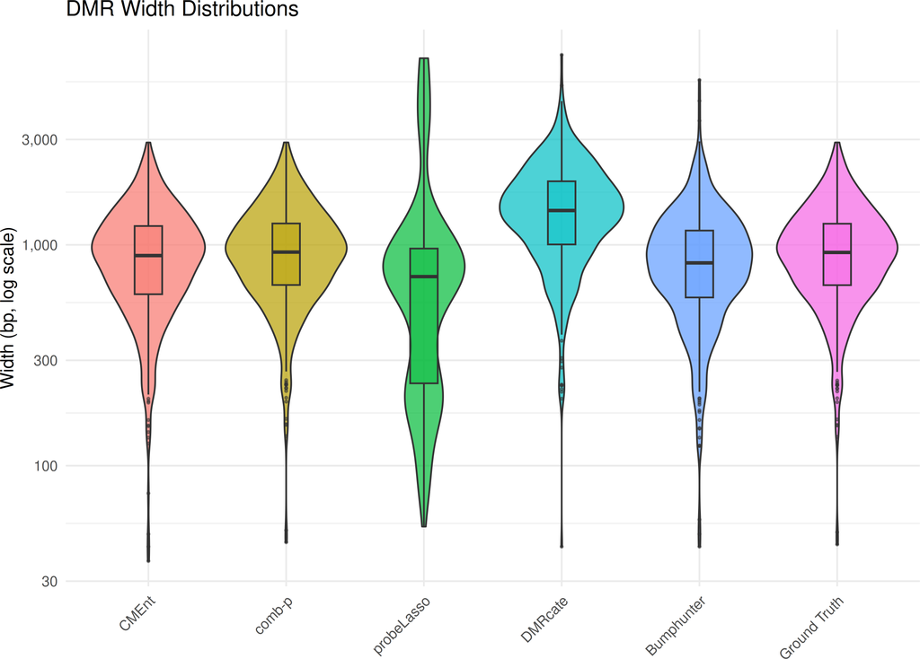

```r
width_data <- do.call(rbind, lapply(names(all_sets), function(method) {
    x <- all_sets[[method]]
    if (length(x) == 0) {
        return(NULL)
    }
    data.frame(Method = method, Width = width(x))
}))
width_data$Method <- factor(width_data$Method, levels = names(all_sets))

ggplot(width_data, aes(x = Method, y = Width, fill = Method)) +
    geom_violin(alpha = 0.7) +
    geom_boxplot(width = 0.2, alpha = 0.5, outlier.size = 0.5) +
    scale_y_log10(labels = scales::comma) +
    theme_minimal() +
    theme(
        axis.text.x = element_text(angle = 45, hjust = 1),
        legend.position = "none"
    ) +
    labs(
        title = "DMR Width Distributions",
        x = "",
        y = "Width (bp, log scale)"
    )
```

## 14 Summary

```r
cat("\n## Key Findings\n\n")
```

## 15 Key Findings

```r
if (nrow(truth_eval) > 0) {
    best_f1 <- truth_eval[which.max(truth_eval$F1_regions), ]
    best_iou <- truth_eval[which.max(truth_eval$IoU_bp), ]

    cat(sprintf(
        "- Best region-level F1: **%s** (%.3f)\n",
        best_f1$Method, best_f1$F1_regions
    ))
    cat(sprintf(
        "- Best base-pair IoU: **%s** (%.3f)\n",
        best_iou$Method, best_iou$IoU_bp
    ))

    if ("CMEnt" %in% truth_eval$Method) {
        seg <- truth_eval[truth_eval$Method == "CMEnt", ]
        cat(sprintf(
            "- **CMEnt** region metrics: Precision = %.3f, Recall = %.3f, F1 = %.3f\n",
            seg$Precision_regions, seg$Recall_regions, seg$F1_regions
        ))
        cat(sprintf(
            "- **CMEnt** base-pair metrics: Precision = %.3f, Recall = %.3f, F1 = %.3f, IoU = %.3f\n",
            seg$Precision_bp, seg$Recall_bp, seg$F1_bp, seg$IoU_bp
        ))
    }
}
```

- Best region-level F1: **Bumphunter** (1.000)
- Best base-pair IoU: **comb-p** (0.989)
- **CMEnt** region metrics: Precision = 0.929, Recall = 1.000, F1 = 0.963
- **CMEnt** base-pair metrics: Precision = 0.965, Recall = 0.994, F1 = 0.979, IoU = 0.959

[session information not shown]

R version 4.6.0 (2026-04-24) Platform: x86_64-pc-linux-gnu Running under: Ubuntu 24.04.4 LTS

Matrix products: default BLAS: /usr/lib/x86_64-linux-gnu/openblas-pthread/libblas.so.3 LAPACK: /usr/lib/x86_64-linux-gnu/openblas-pthread/libopenblasp-r0.3.26.so; LAPACK version 3.12.0

locale: [1] LC_CTYPE=C.UTF-8 LC_NUMERIC=C LC_TIME=C.UTF-8  
[4] LC_COLLATE=C.UTF-8 LC_MONETARY=C.UTF-8 LC_MESSAGES=C.UTF-8  
[7] LC_PAPER=C.UTF-8 LC_NAME=C LC_ADDRESS=C  
[10] LC_TELEPHONE=C LC_MEASUREMENT=C.UTF-8 LC_IDENTIFICATION=C

time zone: Europe/Brussels tzcode source: system (glibc)

attached base packages: [1] parallel stats4 stats graphics grDevices datasets utils  
[8] methods base

other attached packages: [1] dplyr_1.2.1 ggplot2_4.0.3  
[3] data.table_1.18.4 minfi_1.58.0  
[5] bumphunter_1.54.0 locfit_1.5-9.12  
[7] iterators_1.0.14 foreach_1.5.2  
[9] Biostrings_2.80.1 XVector_0.52.0  
[11] SummarizedExperiment_1.42.0 Biobase_2.72.0  
[13] MatrixGenerics_1.24.0 matrixStats_1.5.0  
[15] GenomicRanges_1.64.0 Seqinfo_1.2.0  
[17] IRanges_2.46.0 S4Vectors_0.50.1  
[19] BiocGenerics_0.58.1 generics_0.1.4  
[21] CMEnt_0.99.0 testthat_3.3.2  
[23] BiocStyle_2.40.0